# COMP4010 - Week 1

2024-02-20

# Week 1

# Application Exercises

## Task 1.

- Data: time, geographical location (cities), temperature, weather, number of troops, march direction.
- Mapping: the numbers of men present are mapped to the widths of the colored zones. Red denotes men entering Russia, black denotes those leaving it. The latitude and longitude of city locations are mapped to the x and y axes.
- Statistical transformation: Identity.
- Geometric object: 2D colored zones, lines, text.
- Position adjustment: None
- Scale: the color scale consists of red for entering men and black for leaving men.
- Coordinate system: Map projection.
- Faceting: None.

## Task 2.

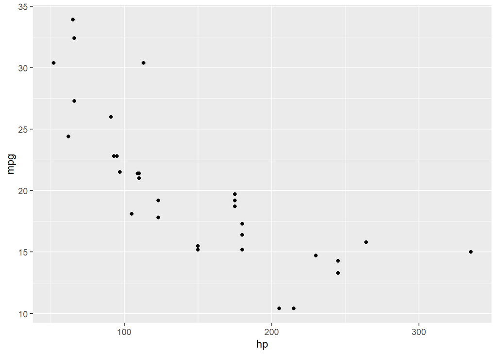

```r
# Your code here
library(ggplot2)
ggplot(data = mtcars, aes(x = hp, y = mpg)) + geom_point()
```

## Task 3.

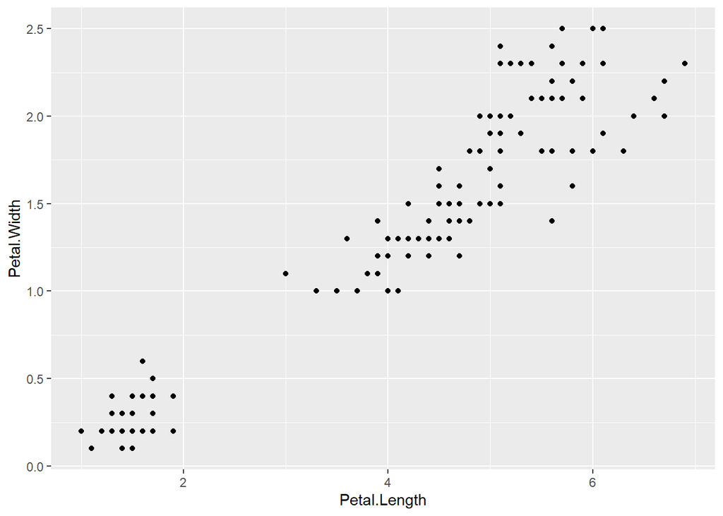

```r
# Your code here
ggplot(data = iris, aes(x = Petal.Length, y = Petal.Width)) + geom_point()
```

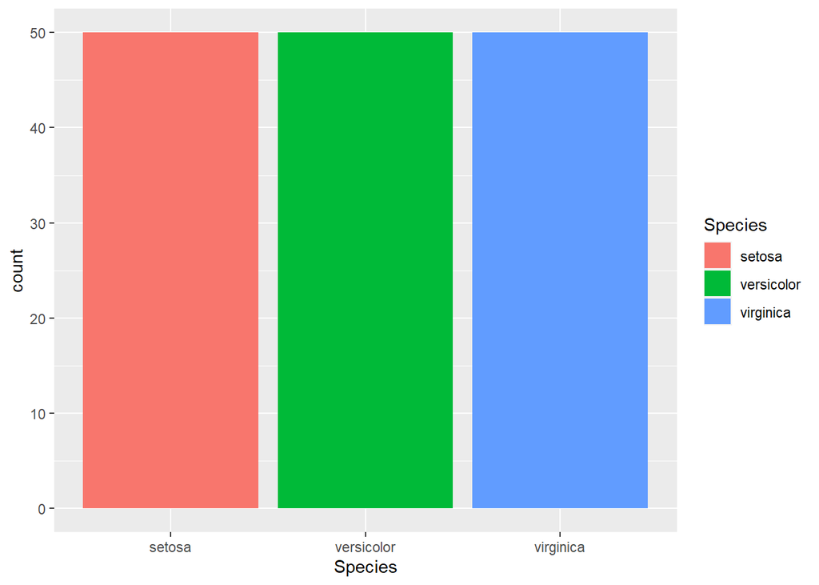

```r
ggplot(data = iris, aes(x = Species, fill = Species)) + geom_bar()
```

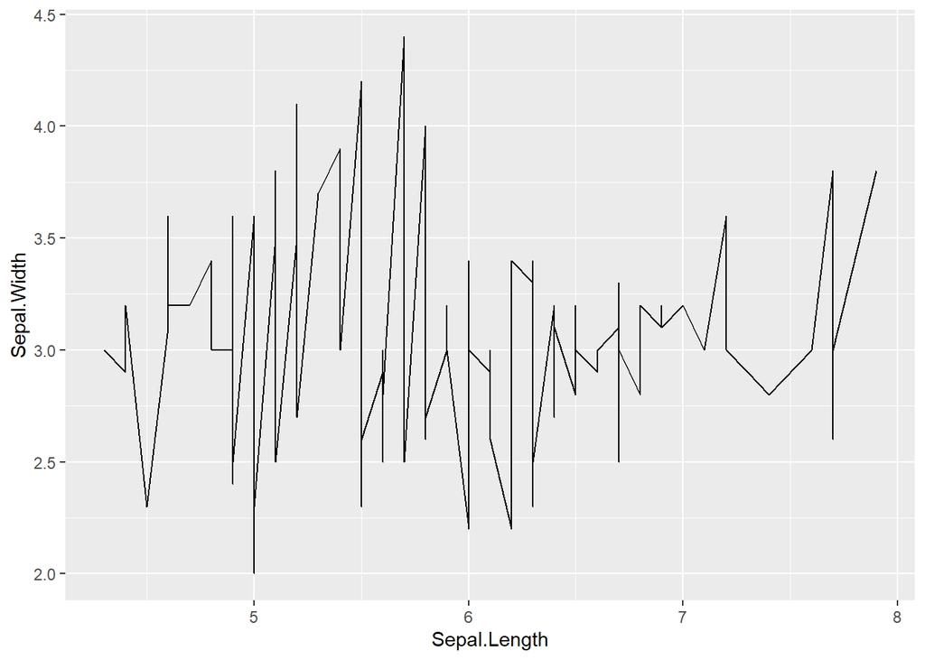

```r
ggplot(data = iris, aes(x = Sepal.Length, y = Sepal.Width)) + geom_line()
```

# Reading Material

## Hello World! but in R

Create a chunk below and create a vector of numbers and calculate its mean. (This is akin to printing ‘Hello World’ in other languages, statisticians are not as fun :D)

```r
myVector <- c(1,2,3,4)
mean(myVector)
```

```
## [1] 2.5
```

## Using CRAN to install ggplot2

Alternatively, you can just run this in the console below.

```r
#install.packages("ggplot2") # uncomment to install
library(ggplot2) # Import
```

## Hello to ggplot2

This uses the built-in `mtcars` dataset. To preview this dataset, you can use `summary(mtcars)` or `View(mtcars)`.

```r
View(mtcars)
```

We can see that there are the `mpg` (miles per gallons) and `wt` (weight) columns in the dataset. Let’s plot the 2 dimensions on the scatterplot using `ggplot2`.

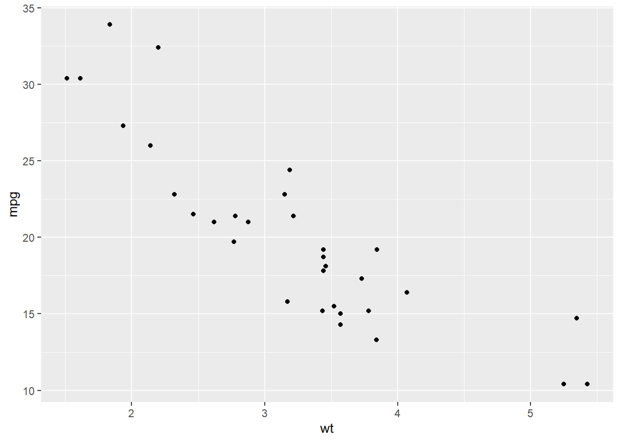

```r
ggplot(data = mtcars, aes(x = wt, y = mpg)) + geom_point()
```

## Bar chart with iris dataset

We can also try making a bar chart with the built-in `iris` dataset.

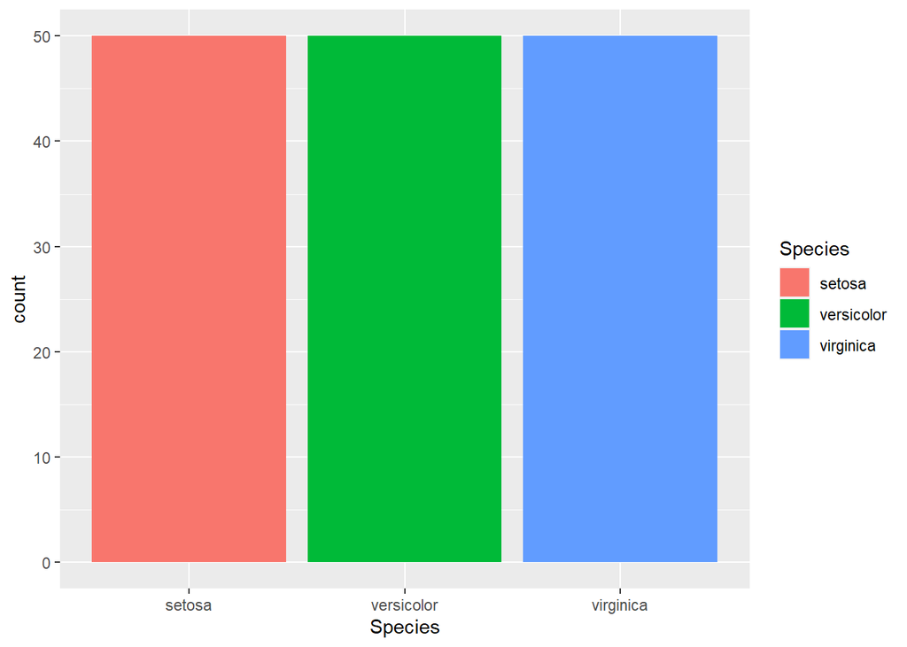

```r
ggplot(data = iris, aes(x = Species, fill = Species)) + geom_bar()
```

## Customizing plots

Adding titles and labels:

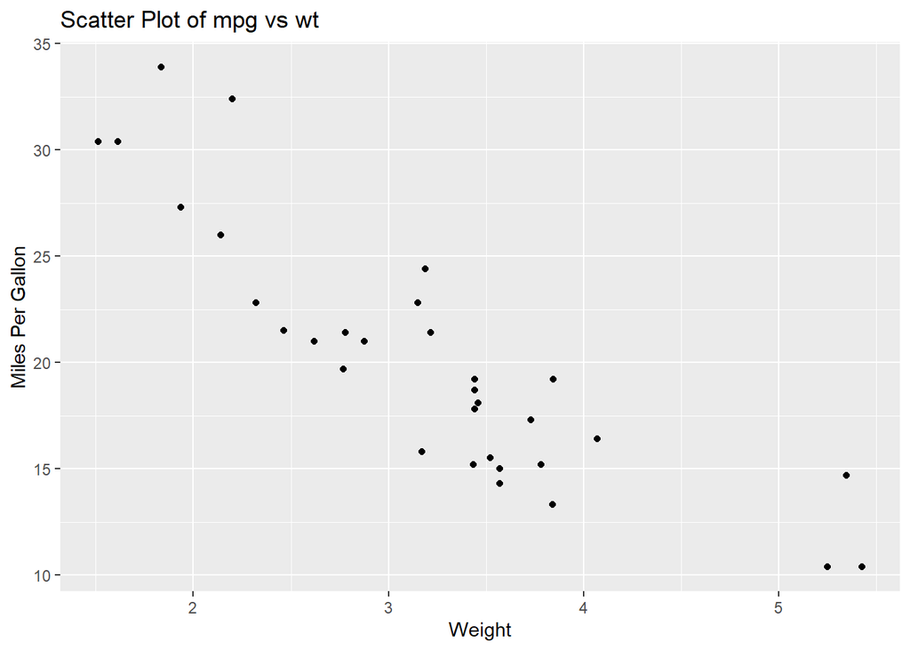

```r
ggplot(data = mtcars, aes(x = wt, y = mpg)) +
  geom_point() +
  ggtitle("Scatter Plot of mpg vs wt") +
  xlab("Weight") +
  ylab("Miles Per Gallon")
```

Changing colors:

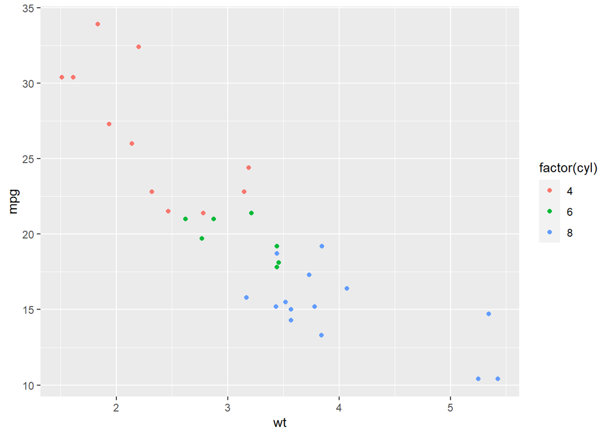

```r
ggplot(data = mtcars, aes(x = wt, y = mpg, color = factor(cyl))) +
  geom_point()
```

### Experimenting with the Iris Dataset

- **Dataset**: Iris (available in R by default)
- **Task**: Create a scatter plot showing the relationship between petal length and petal width, colored by species.
- **Customization**: Add a smooth regression line for each species.

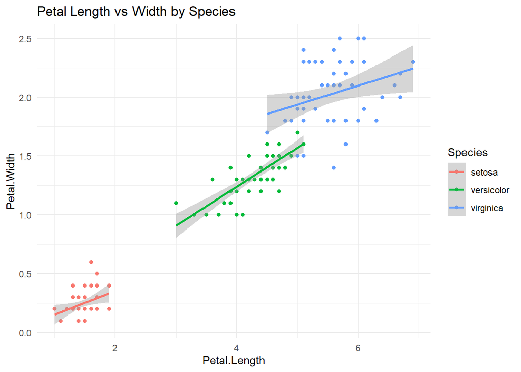

```r
ggplot(iris, aes(x = Petal.Length, y = Petal.Width, color = Species)) +
    geom_point() +
    geom_smooth(method = "lm") +
    ggtitle("Petal Length vs Width by Species") +
    theme_minimal()
```

### Visualizing the mtcars Dataset

- **Dataset**: mtcars (available in R by default)
- **Task**: Create a bar plot showing the average miles per gallon (mpg) for cars with different numbers of cylinders.
- **Customization**: Use a different fill color for each cylinder type and add labels for the average mpg.

```
## No summary function supplied, defaulting to `mean_se()`
```

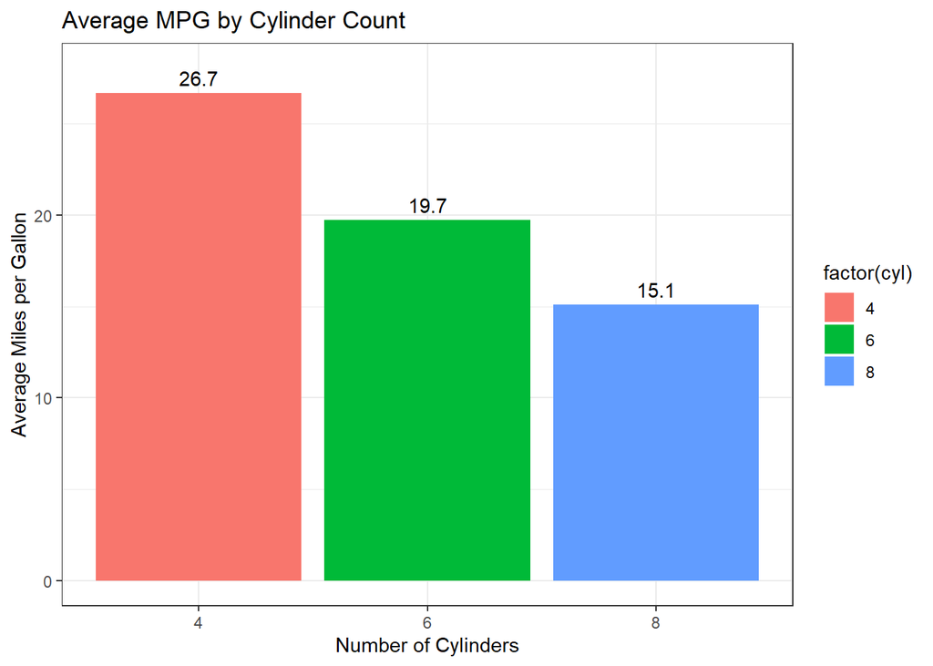

```r
ggplot(mtcars, aes(x = factor(cyl), y = mpg, fill = factor(cyl))) +
    geom_bar(stat = "summary", fun = mean) +
    geom_text(stat = 'summary', aes(label = round(..y.., 1)), vjust = -0.5) +
    labs(x = "Number of Cylinders", y = "Average Miles per Gallon", title = "Average MPG by Cylinder Count") +
    theme_bw()
```

### Exploring the gapminder Dataset

- **Dataset**: gapminder (install using **`install.packages("gapminder")`** and then **`library(gapminder)`**)
- **Task**: Create a line plot showing GDP per capita over time for select countries.
- **Customization**: Use different line types and colors for each country.

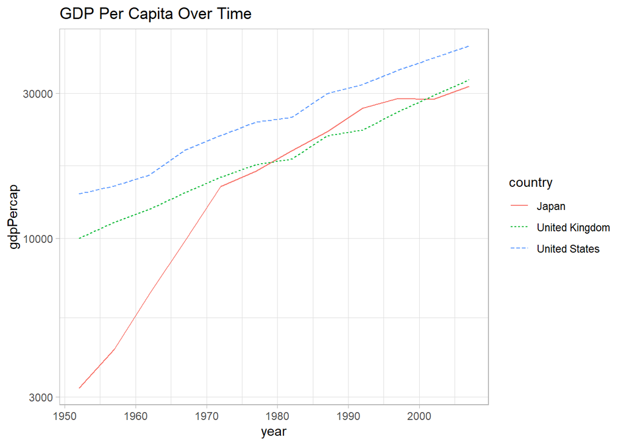

```r
# install.packages("gapminder")
library(gapminder)
ggplot(subset(gapminder, country %in% c("Japan", "United Kingdom", "United States")),
       aes(x = year, y = gdpPercap, color = country, linetype = country)) +
    geom_line() +
    scale_y_log10() +
    ggtitle("GDP Per Capita Over Time") +
    theme_light()
```

### Working with the diamonds Dataset

- **Dataset**: diamonds (part of ggplot2 package)
- **Task**: Create a histogram of diamond prices, faceted by cut quality.
- **Customization**: Adjust the bin width and use a theme that enhances readability.

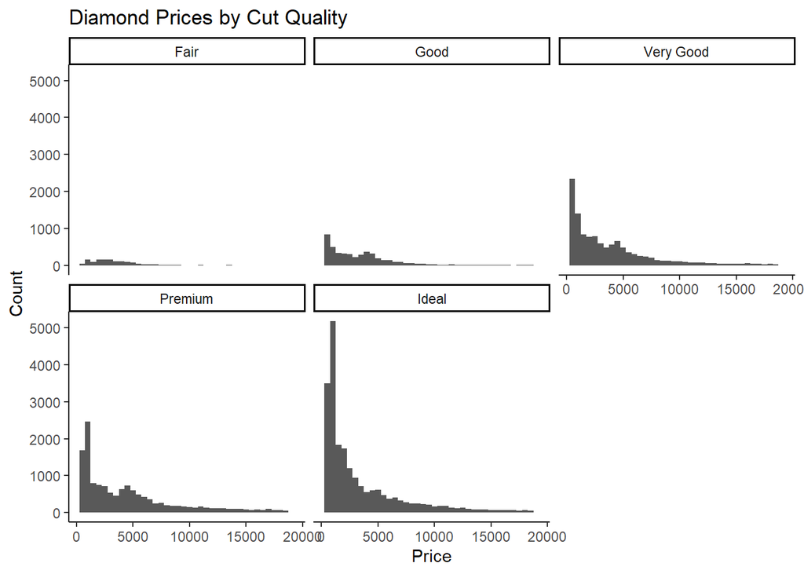

```r
ggplot(diamonds, aes(x = price)) +
    geom_histogram(binwidth = 500) +
    facet_wrap(~cut) +
    labs(title = "Diamond Prices by Cut Quality", x = "Price", y = "Count") +
    theme_classic()
```